# solution_script

Charles

2022-08-21

## **Description**

The task consists of finding groups or clusters of patients within a study. The study consists of 49 patients (observations) who provided responses to 12 factors (features) that motivate them. Each value is the mean value of about 7 questions an individual answered within the particular feature.

This is basically an unsupervised clustering problem. Clustering is a form of exploratory data analysis (EDA) whereby observations are grouped into meaningful groups, based on the features they share.

I will use various approaches to identify and confirm the optimal number of groups of patients within the dataset as well as the features that drive these groupings. These approaches will fall under the following milestones:

1. Data pre-processing
2. Selection of similarity metric
3. Clustering
4. Analyses

## **To load the libraries.**

```r
library(openxlsx) # to read in excel files
library(ggplot2) # for plotting
library(purrr) # tools for vector and function manipulation
library(dplyr) # data wrangling
library(tidyr) # data wrangling
library(rafalib) # optimising graphical parameters.
library(cluster) # cluster analysis
library(corrplot) # plotting correlation plot
library(rpart) # perform recursive partitioning
library(genefilter) # for variation analysis.
library(RColorBrewer) # for colouring
library(gplots) # for plotting
library(fpc) # clustering and cluster validation
```

## **To load in the dataset.**

```r
# to see files in the directory
list.files("raw_data")
```

```
## [1] "Vinyu_Motivation_Challenge_Test.xlsx"
```

```r
# read in the data
raw_data <- read.xlsx("raw_data/Vinyu_Motivation_Challenge_Test.xlsx",
                      rowNames = TRUE)
```

## **Step 1: Data pre-processing.**

This is to explore for the presence of missing values and to make sure that the data are on the same scale. This is because the values for the different variables are unlikely to be on the same scale.

### **i. Checking for missing values.**

```r
# check for NAs
anyNA(raw_data)
```

```
## [1] FALSE
```

```r
# inspect
View(raw_data)

dim(raw_data)
```

```
## [1] 49 12
```

The result shows the absence of missing values in the dataset, as well as the presence of 49 observations and 12 features.

### **ii. Standardising the the features.**

I will perform standardisation. This will help make the data comparable, since it is unlikely that they were measured on the same scale or the same manner for all variables. Without standardisation, distances between samples may become exaggerated and unmeaningful or difficult to interpret. I will make use of base R’s $scale()$ function. Each feature column will be normalised to a mean of 0 and a variance of 1.

```r
# scale the data
scaled_data <- scale(raw_data)

# inspect
head(scaled_data)
```

```
##    Macht_und_Einfluss Gemeinschaftssinn  Neugierde Wertschaetzung    Sammler
## P1        -1.34192350       -0.76810430 -2.4305745     -2.3107430 -0.4591764
## P2        -0.29153610        0.04420744  0.6076436     -0.6456488  0.7793361
## P3         1.17900627        0.85651919 -0.9114654      0.3534077  0.5729173
## P4         1.38908375       -0.49733372  0.9114654     -0.3126299  0.5729173
## P5        -0.71169106       -0.22656314 -0.6076436      0.3534077  0.3664986
## P6        -0.08145861        1.12728977 -1.2152872      0.6864266 -0.6655951
##    Zielbewusstsein      Essen   Bewegung Emotionale_Ruhe    Ordnung
## P1     -0.09157314 -1.8169065 -0.3572518      -2.1643346 -1.5258621
## P2     -0.98898992  1.1057436 -1.7302195       0.1923853 -1.5258621
## P3      0.80584364  1.1057436  1.1873368       0.7815653  0.8477012
## P4     -0.09157314  0.8809243  0.1576111       0.7815653  0.6103449
## P5      0.50670471  0.4312859 -0.5288727       0.4869753  0.6103449
## P6      0.50670471 -1.8169065 -1.0437356       0.7815653  0.1356322
##    Eros_und_Schoenheit  Wettkampf
## P1          -1.1178074 -0.6006191
## P2          -0.1933760 -0.3688842
## P3           1.1932712  1.0215254
## P4           0.9621634  0.7897905
## P5          -0.4244838 -0.3688842
## P6          -0.8866996  0.7897905
```

## **Step 2: The similarity metric.**

The similarity metric I will use is the **distance**. For hierarchical clustering, I will compute the distance between the samples, using the **stats** package’s $dist()$ function which calculates the Euclidean distance by default.

```r
# calculate the distance
dist_scaled_data <- dist(scaled_data)
```

## **Step 3: Clustering.**

For the clustering, I will explore hierarchical and k-means clustering thanks to their suitability.

### **i. Hierarchical clustering.**

I will perform hierarchical clustering based on the distances defined above using the $hclust()$ function. This function returns an `hclust` object that describes the groupings that were created using the algorithm described above. The $plot()$ function represents these relationships with a tree or dendrogram.

```r
# for improved graphics
mypar()

# perform hclust
hc_complete <- hclust(dist_scaled_data,
                      method = "complete")
hc_complete
```

```
##
## Call:
## hclust(d = dist_scaled_data, method = "complete")
##
## Cluster method   : complete
## Distance         : euclidean
## Number of objects: 49
```

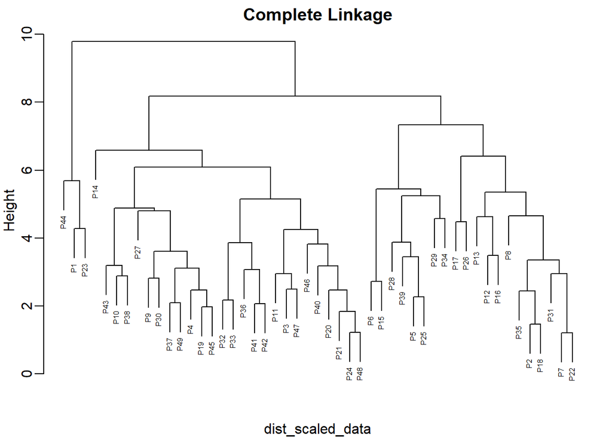

```r
# plot
plot(hc_complete, cex = 0.5, asp = 1,
     main = 'Complete Linkage')
```

```r
# saving plot
pdf(file="figures/hc_complete.pdf")

plot(hc_complete, cex = 0.5, asp = 1,
     main = 'Complete Linkage')

dev.off()
```

The hierarchical clustering with complete linkage is consistent with the existence of two main clusters, one containing patients P1, P23 and P44 and the other one containing the rest of the patients. The other main cluster has two main sub-clusters. From eye observation, I define three clusters, and I cut the tree at height value 8 and group all samples that are within that distance into groups below. To visualize this, I will draw a broken red horizontal line at the height = 8.

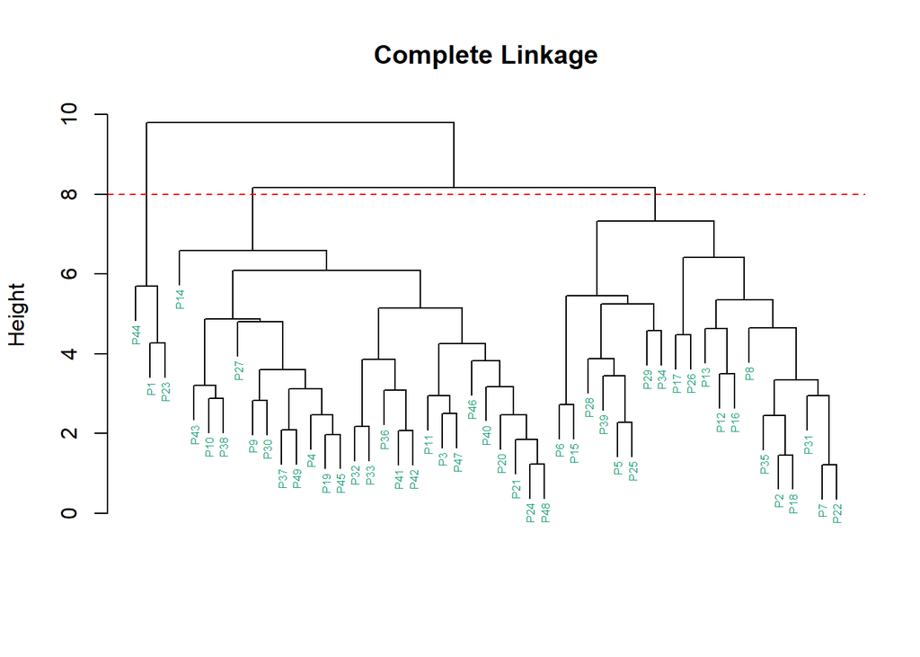

```r
# plot
myplclust(hc_complete, cex = 0.5, asp = 1,
     main = "Complete Linkage")
abline(h = 8, col = "red",
       lty = 2) # dashed line at h = 8
```

```r
# save plot
pdf(file="figures/hc_complete_h8.pdf")

myplclust(hc_complete, cex = 0.5, asp = 1,
     main = "Complete Linkage")
abline(h = 8, col = "red",
       lty = 2) # dashed line at h = 8

dev.off()
```

```r
# cut tree
hclusters <- cutree(hc_complete, h = 8)
print(hclusters)
```

```
##  P1  P2  P3  P4  P5  P6  P7  P8  P9 P10 P11 P12 P13 P14 P15 P16 P17 P18 P19 P20
##   1   2   3   3   2   2   2   2   3   3   3   2   2   3   2   2   2   2   3   3
## P21 P22 P23 P24 P25 P26 P27 P28 P29 P30 P31 P32 P33 P34 P35 P36 P37 P38 P39 P40
##   3   2   1   3   2   2   3   2   2   3   2   3   3   2   2   3   3   3   2   3
## P41 P42 P43 P44 P45 P46 P47 P48 P49
##   3   3   3   1   3   3   3   3   3
```

```r
# see distribution of patients per cluster
table(hclusters)
```

```
## hclusters
##  1  2  3
##  3 20 26
```

Results show which cluster each patient belongs to. The most populated clusters are clusters 3 and 2 while cluster 1 is the least. Cluster 1 contains P1, P23 and P44.

By default, $hclust()$ implements clustering via complete linkage. The choice of linkage method can affect clustering results. I will explore the other two possible linkage methods. These are the **single** and **average linkage** methods.

```r
# single linkage
hc_single <- hclust(dist_scaled_data, method = "single")
hc_single
```

```
##
## Call:
## hclust(d = dist_scaled_data, method = "single")
##
## Cluster method   : single
## Distance         : euclidean
## Number of objects: 49
```

```r
# average linkage
hc_average <- hclust(dist_scaled_data, method = "average")
hc_average
```

```
##
## Call:
## hclust(d = dist_scaled_data, method = "average")
##
## Cluster method   : average
## Distance         : euclidean
## Number of objects: 49
```

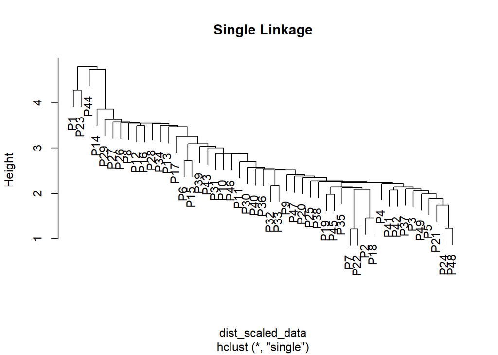

```r
# plot all linkage methods
plot(hc_single, main = 'Single Linkage',
     cex = 1, asp = 1)
```

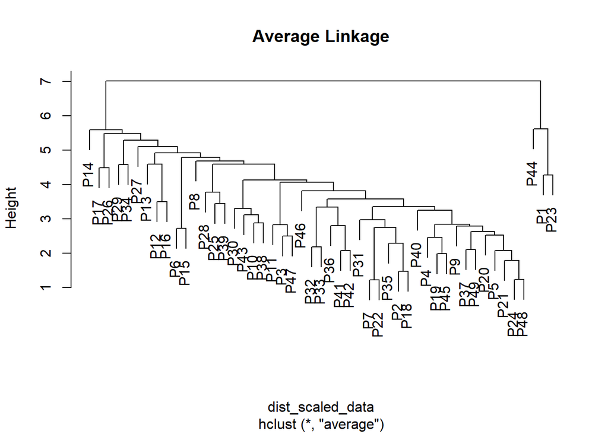

```r
plot(hc_average, main = 'Average Linkage',
     cex = 1, asp = 1)
```

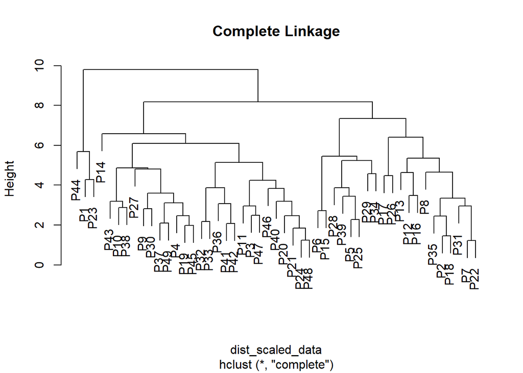

```r
plot(hc_complete, cex = 1, asp = 1,
     main = 'Complete Linkage')
```

```r
# save linkage plots
pdf(file = "figures/compare_linkages.pdf",
    height = 5, width = 15)

par(mfrow = c(1,3)) # one row and 3 columns
plot(hc_single, main = 'Single Linkage')
plot(hc_average, main = 'Average Linkage')
plot(hc_complete, cex = 0.5, asp = 1,
     main = 'Complete Linkage')

dev.off()
```

The results of the linkage methods consistently detect two major clusters, with patients P1 and P23 always being in the same major cluster. The average and complete linkage methods are similar in that they both cluster patients P1, P23 and P44 together.

### **ii. K-Means clustering.**

We can also cluster with the **stats** package’s $kmeans()$ function to perform k-means clustering. To use kmeans clustering, I will empirically estimate the optimal number of ks (clusters) to be used, using two approaches:

#### **Estimation by total within-cluster sum of squares.**

I will use $map\_dbl()$ from the **purrr** package to run k-means using values of k ranging from 1 to 10 and extract the total within-cluster sum of squares.

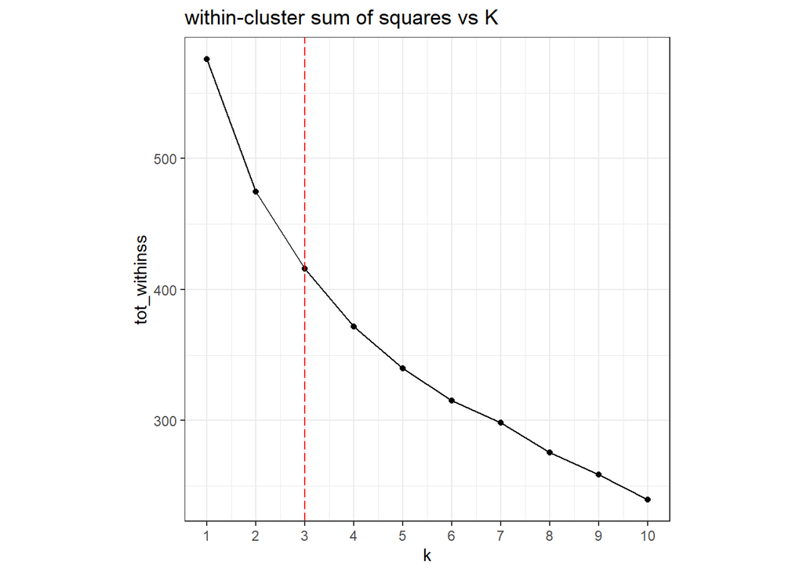

```r
# Use map_dbl to run many models with varying value of k (centers)
set.seed(1) # for reproducibility
tot_withinss <- map_dbl(1:10,  function(k){
  model <- kmeans(x = scaled_data, centers = k)
  model$tot.withinss
})

# Generate a data frame containing both k and tot_withinss
elbow_df <- data.frame(
  k = 1:10,
  tot_withinss = tot_withinss
)

# Plot the elbow plot
ggplot(elbow_df, aes(x = k, y = tot_withinss)) +
  ggtitle("within-cluster sum of squares vs K") +
  geom_point() +
  geom_line() +
  geom_vline(xintercept = c(3),
             linetype = "longdash", colour = "red") +
  scale_x_continuous(breaks = 1:10) +
  theme_bw() +
  theme(aspect.ratio = 1)
```

```r
ggsave("figures/within_cluster_squares.pdf",
       height = 5, width = 5, dpi = 300)
```

The plot of the total within-cluster sum of squares **tot_withinss**, against the number of clusters **k** shows that the curve begins to flatten out more at **k = 3**. So I use **3** as the best estimated value of **k**.

#### **Estimation by Silhouette analysis.**

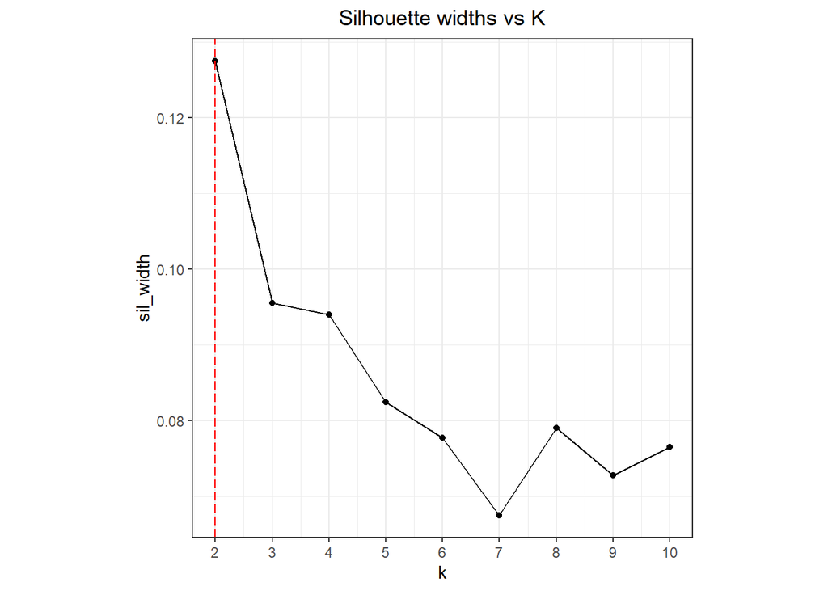

```r
# Use map_dbl to run many models with varying value of k
sil_width <- map_dbl(2:10,  function(k){
  set.seed(1) # for reproducibility
  model <- pam(x = scaled_data, k = k)
  model$silinfo$avg.width
})

# Generate a data frame containing both k and sil_width
sil_df <- data.frame(
  k = 2:10,
  sil_width = sil_width
)

# Plot the relationship between k and sil_width
ggplot(sil_df, aes(x = k, y = sil_width)) +
  geom_point() +
  geom_line() +
  ggtitle("Silhouette widths vs K") +
    geom_vline(xintercept = c(2),
             linetype = "longdash", colour = "red") +
  scale_x_continuous(breaks = 2:10) +
  theme_bw() +
  theme(aspect.ratio = 1,
         plot.title = element_text(hjust=0.5)) # center title test
```

```r
ggsave("figures/silhoutte_width_vs_k.pdf",
       height = 5, width = 5, dpi = 300)
```

```r
# perform kmeans
set.seed(1) # for reproducibilitys
km <- kmeans(scaled_data, centers = 3)
```

To visualise the kmeans clustering results I use two approaches.

**The Discriminant Projection plot.**

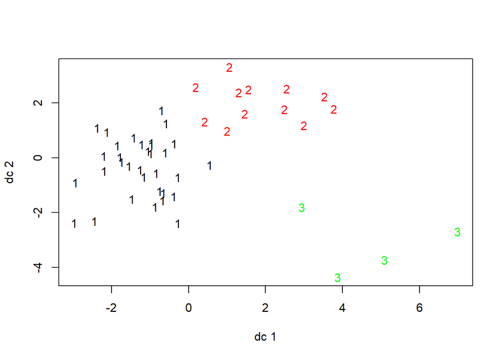

```r
# visualise clustering
plotcluster(scaled_data, km$cluster)
```

```r
# save plot
pdf(file = "figures/dc_plot.pdf",
    height = 5, width = 5)

plotcluster(scaled_data, km$cluster)

dev.off()
```

The $plotcluster()$ function derives from the **fpc** package and its results shows the presence of three clusters, 1, 2 and 3. Please note that the ordering of the clusters is not same as that derived from the hierarchical clustering. The horizontal and vertical axes, represent **discriminant coordinates** (dc), which represent a space convenient for presenting multidimensional data originating from multiple groups and for the use of various classification methods.

**The Bivariate Cluster Plot.**

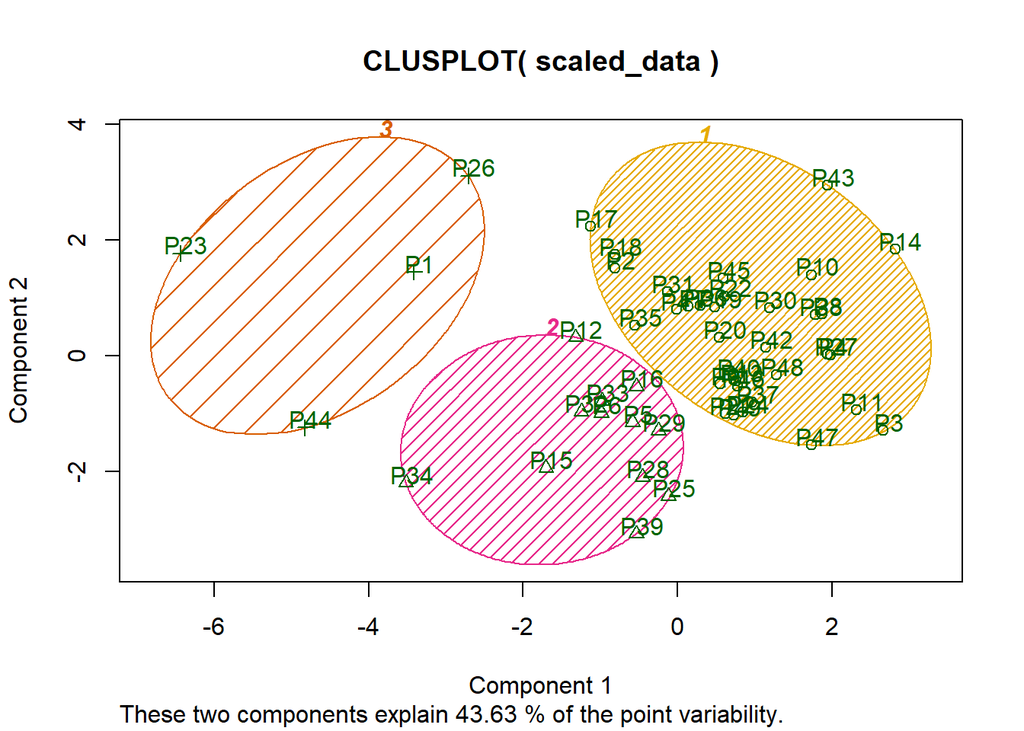

```r
# plot
clusplot(scaled_data, km$cluster,
         color = TRUE, shade = TRUE,
         labels = 2, lines = 0)
```

```r
# save plot
pdf(file = "figures/bivariate_clustering.pdf",
     height = 5, width = 5)

clusplot(scaled_data, km$cluster,
         color = TRUE, shade = TRUE,
         labels = 2, lines = 0)

dev.off()
```

The $clusplot()$ function is derived from the **cluster** package. Its results are consistent with the one derived from Discriminant Projection Plot. Just like the hierarchical clustering, it shows that the least populated cluster, in this case cluster 3, contains 4 members, being P1, P23 and P44 but also includes P26.

## **Step 4: Analyses.**

### **i. Principal components analysis to identify influential features.**

I perform PCA to identify features that determine the positions of the patients on the principal components and also if there are more hidden structures within the data set. I will use the $prcomp()$ function from the **stats** package.

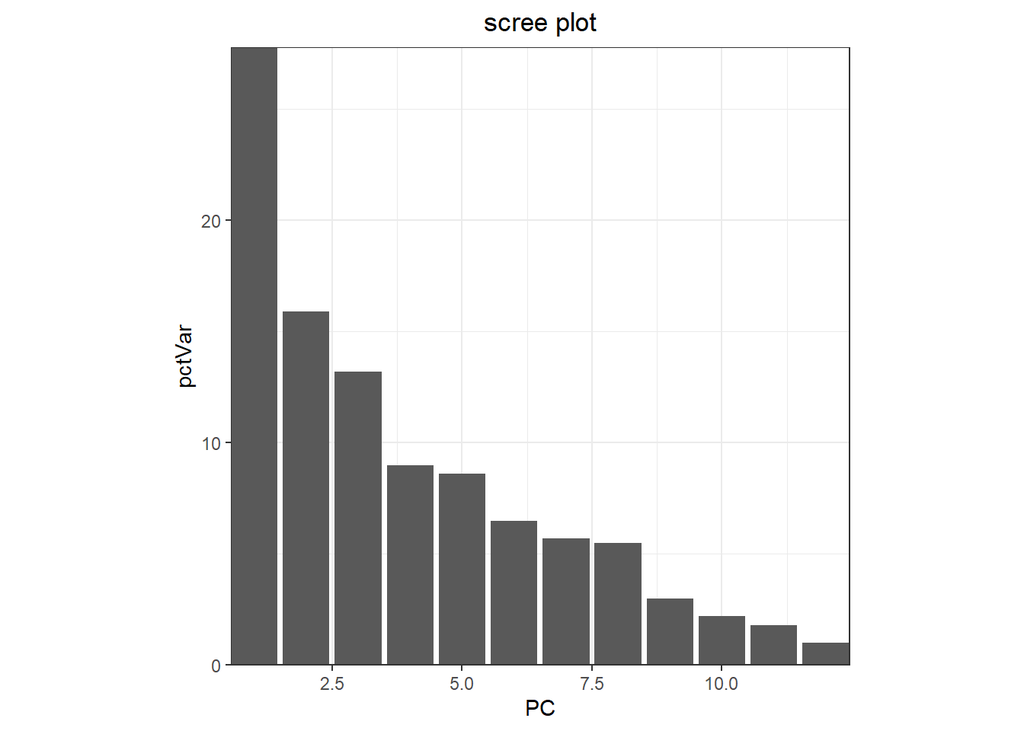

```r
# to do PCA: I fit in the raw data
# because I set scale parameter to True
pca <- prcomp(raw_data, scale. = TRUE)

# obtain variance of each PC
pcaVar <- pca$sdev ** 2

# obtain percentage variance from each PC
pctVar <- round(pcaVar / sum(pcaVar) * 100, 1)

# create data frame
pctVar <- as.data.frame(pctVar)

pctVar$PC <- 1:dim(pctVar)[1]

# save variations per PC
write.xlsx(pctVar,
           "results/var_explained_per_PC.xlsx",
           rowNames = TRUE)

# make scree plot
ggplot(pctVar, aes(PC, pctVar)) +
  ggtitle("scree plot") +
  geom_bar(stat = "identity") +
  scale_x_continuous(expand = c(0, 0)) +
  scale_y_continuous(expand = c(0, 0)) +
  theme_bw() +
  theme(aspect.ratio = 1,
        plot.title=element_text(hjust=0.5)) # centralise plot title
```

```r
ggsave("figures/PctVar_vs_PC.pdf",
        height = 5, width = 5, dpi = 300)
```

The scree plot shows that PC1 accounts for almost **30%** of the total variance. But PC2 and PC2 also account for a considerable amount of variance being **16%** and **13%** respectively. This necessitates further analyses to discover more hidden structures within the dataset. This can be done using the [surrogate value analysis or sva](https://bioconductor.org/packages/release/bioc/html/sva.html). However to do a good sva, I need more metadata which is currently unavailable.

**Plotting the PCA.**

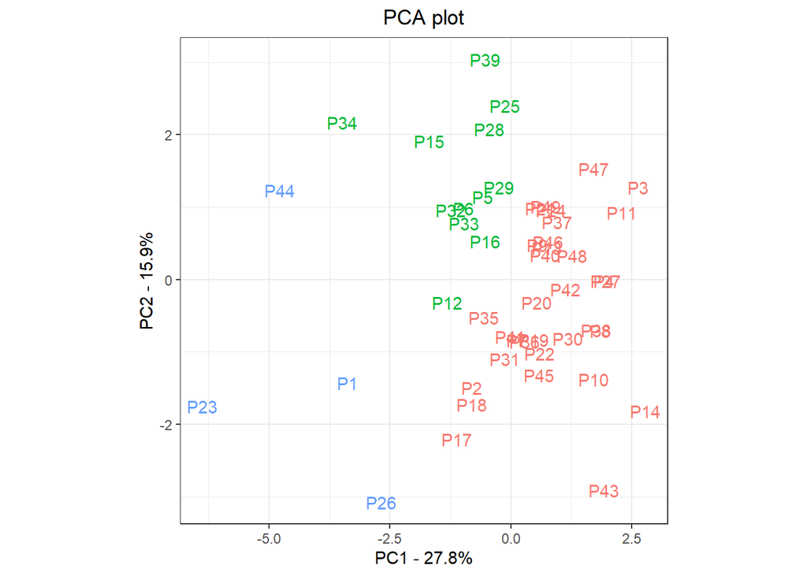

```r
# prepare data frame of PCA details
pca_df <- data.frame(samples = rownames(pca$x),
                     X = pca$x[, 1],
                     Y = pca$x[, 2])

# add cluster information
pca_df$cluster <- km$cluster

ggplot(pca_df, aes(x = X, y = Y,
                   label = samples),
       fill = cluster) +
  ggtitle("PCA plot") +
  geom_text(aes(colour = factor(cluster)),
            show.legend = FALSE) +
  xlab(paste0("PC1 - ", pctVar[1, 1], "%")) +
  ylab(paste0("PC2 - ", pctVar[2, 1], "%")) +
  theme_bw() +
  theme(aspect.ratio = 1,
        plot.title = element_text(hjust=0.5))
```

```r
ggsave("figures/patient_grouping_on_PC.pdf",
        height = 5, width = 5, dpi = 300)
```

Just like the hierarchical clustering, the PCA plot of the first two principal components shows that P1, P23, and P44 form a cluster separated from the rest. However at the PCA level, P26 appears to highly correlate with P1, P23 and P44, a feature which hierarchical clustering misses out, but is also captured by the various clustering approaches used above to visualise kmeans clustering.

To find out the most influential features on the first PC, the loading scores need to be assessed.

```r
# obtain loading scores
loading_scores <- pca$rotation[, 1]

# obtain the absolute values.
feature_scores <- abs(loading_scores)

# sort loading scores in decreasing order
feature_scores_ranked <- sort(feature_scores,
                              decreasing = TRUE)

# inspect loading scores.
loading_scores[names(feature_scores_ranked)]
```

```
##  Macht_und_Einfluss Eros_und_Schoenheit           Wettkampf               Essen
##          0.44343562          0.44185262          0.43161934          0.37626211
##            Bewegung   Gemeinschaftssinn             Ordnung           Neugierde
##          0.29540935          0.24905219          0.23652725          0.18787287
##      Wertschaetzung             Sammler     Zielbewusstsein     Emotionale_Ruhe
##          0.12708496          0.10920212          0.09188092         -0.05665553
```

### **ii. Correlation analysis.**

I perform a Spearman correlation analysis, to confirm findings from the PCA plot to see how features correlate with each other. I use Spearman correlation so that I will be able to capture non-linear relationships, which Pearson correlation will not capture.

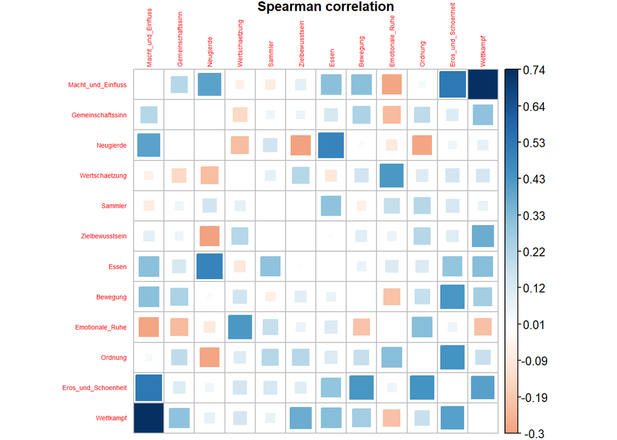

```r
# calculate Spearman correlation.
the_cor <- cor(scaled_data, method = "spearman")

# plot correlation
corrplot(the_cor, diag = FALSE,
         hclust.method = "complete",
         is.corr = FALSE,
         tl.cex = 0.45,
         method = "square")
title("Spearman correlation", line = 3.5,
      cex.main = 0.9)
```

```r
# save correlation plot
pdf(file = "figures/Spearman_cor.pdf",
    height = 8, width = 8)

corrplot(the_cor, diag = FALSE,
         hclust.method = "complete",
         is.corr = FALSE,
         tl.cex = 0.9,
         method = "square")
title("Spearman correlation", line = 3)

dev.off()
```

The results confirm that **Macht_und_Einfluss** has its strongest positive correlation with **Eros_und_Schoenheit**, **Wettkampf** and negatively correlates with **Emotionale_Rule**.

### **iii. Recursive partitioning.**

Recursive partitioning is a tree-based classification method, that can help in finding out the most important feature helpful to classify the patients. It is implemented in the $rpart()$ function from the **rpart** package.

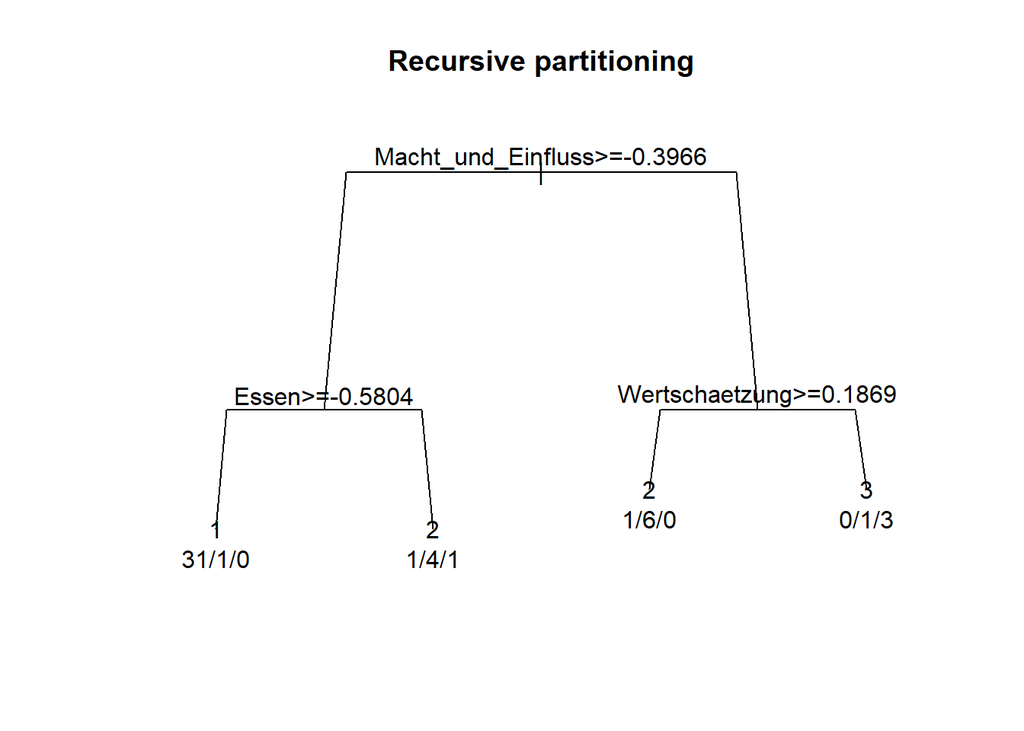

```r
# prepare data frame for recursive partitioning
scaled_data_df <- as.data.frame(scaled_data)

# add km cluster information.
scaled_data_df$cluster <- km$cluster

# do recursive partitioning
set.seed(1)
rp <- rpart(cluster ~ ., # use all features
            method = "class", # perform classification
            data = scaled_data_df,
            control = rpart.control(minsplit = 11))

# plot
plot(rp, branch = 0.9, margin = 0.1); text(rp, digits = 3, use.n = TRUE); title("Recursive partitioning")
```

```r
# save plot
pdf(file="figures/rpart.pdf",
    height = 8, width = 8)

# plot
plot(rp, branch = 0.9, margin = 0.1); text(rp, digits = 3, use.n = TRUE); title("Recursive partitioning")

dev.off()
```

**rpart** analysis shows that, **Macht_und_Einfluss** is the strongest factor differentiating between cluster 3 from clusters 1 and 2. Cluster 1 and 2 members are strongly motivated by **Macht_und_Einfluss** compared to members of clusters 3. This is in line with the loading scores analysis from PC1 above. To separate clusters 1 and 2, **rpart** shows that cluster 1 has a higher motivation for **Essen** than members of cluster 2.

Plotting the **variable importance** shows that **Essen** and **Macht_und_Einfluss** are the strongest distinguishing features in the dataset, in line with the results from the PCA analysis above.

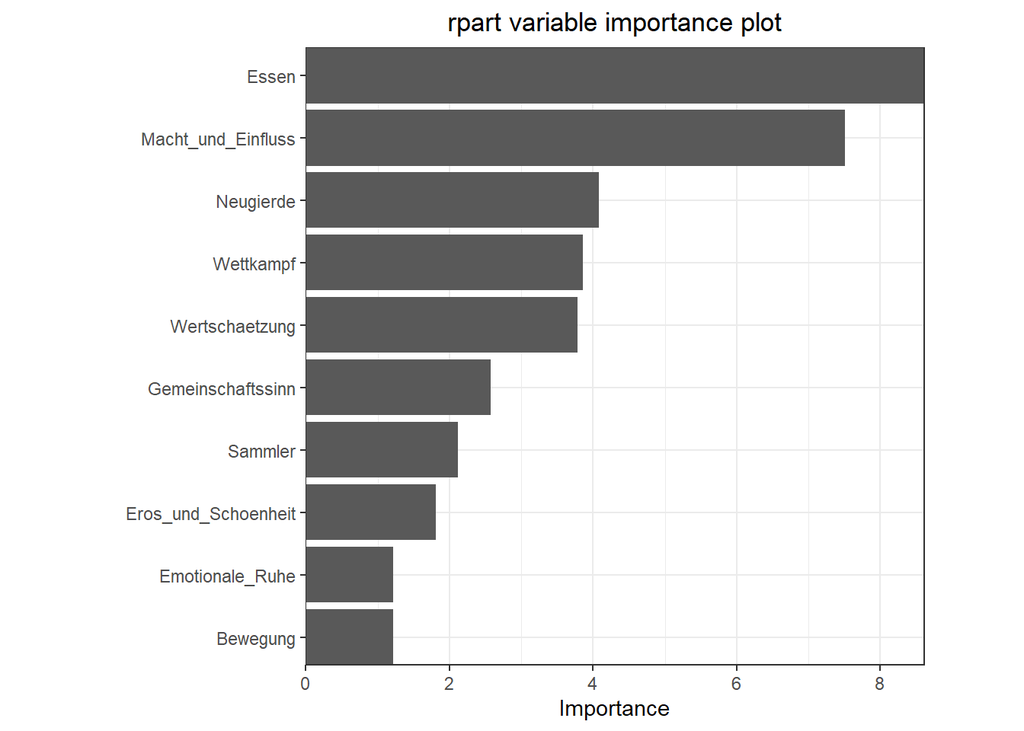

```r
# plot the variable importance
vip::vip(rp) +
  ggtitle("rpart variable importance plot") + # set title
  scale_x_discrete(expand = c(0, 0)) + # remove v space
  scale_y_continuous(expand = c(0, 0)) + # remove h space
  theme_bw() + # remove background gray colour
  theme(aspect.ratio = 1,
        plot.title = element_text(hjust=0.5)) # centralise title text
```

```r
ggsave("figures/var_importance.pdf",
       height = 5, width = 5, dpi = 300)
```

### **iv. Heatmap visualisation.**

```r
# select variable features
rv <- rowVars(t(scaled_data))

# order varies features in decreasing order
idx <- order(-rv)

# adding cluster information
clusters <- km$cluster

# setting cluster colours.
cols <- palette(brewer.pal(8,
                           "Dark2"))[as.numeric(clusters)]

hmcol <- colorRampPalette(brewer.pal(9, "GnBu"))(100)

head(cbind(colnames(scaled_data),cols))
```

```
##                           cols
## [1,] "Macht_und_Einfluss" "#7570B3"
## [2,] "Gemeinschaftssinn"  "#1B9E77"
## [3,] "Neugierde"          "#1B9E77"
## [4,] "Wertschaetzung"     "#1B9E77"
## [5,] "Sammler"            "#D95F02"
## [6,] "Zielbewusstsein"    "#D95F02"
```

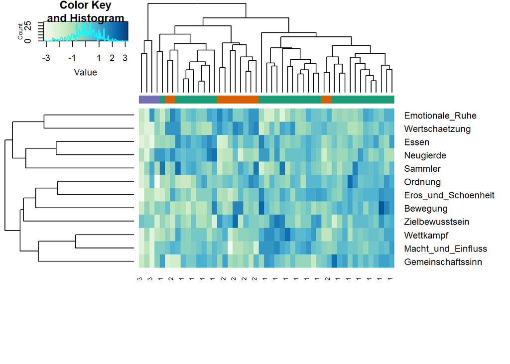

```r
# plot heatmap
set.seed(1)
heatmap.2(t(scaled_data)[idx,],
          labCol = clusters,
          trace = "none",
          keysize = 1.5,
          ColSideColors = cols,
          margins = c(10,12),
          col = hmcol)
```

```r
# save heatmap
pdf(file = "figures/heatmap.pdf",
    height = 8, width = 8)

# plot
set.seed(1)
heatmap.2(t(scaled_data)[idx,],
          labCol = clusters,
          trace = "none",
          keysize = 1.5,
          ColSideColors = cols,
          margins = c(10,12),
          col = hmcol)

dev.off()
```

It is noticeable on the heatmap that members of cluster 3 are in general the least motivated given most of the variables.